# TMDB Movies Analysis

## Udacity investigate a Dataset Project

For this project, I chose the TMDB movies dataset

```python
# Importing the necessary libraries and the dataset:

import numpy as np
import pandas as pd
import matplotlib.pyplot as plt
import seaborn as sns

%matplotlib inline

df = pd.read_csv("tmdb-movies.csv")
```

```python
# Viewing the first few lines of the dataset:

df.head()
```

|  | id | imdb_id | popularity | budget | revenue | original_title | cast | homepage | director | tagline | ... | overview | runtime | genres | production_companies | release_date | vote_count | vote_average | release_year | budget_adj | revenue_adj |
| --- | --- | --- | --- | --- | --- | --- | --- | --- | --- | --- | --- | --- | --- | --- | --- | --- | --- | --- | --- | --- | --- |
| 0 | 135397 | tt0369610 | 32.985763 | 150000000 | 1513528810 | Jurassic World | Chris Pratt\|Bryce Dallas Howard\|Irrfan Khan\|Vi... | http://www.jurassicworld.com/ | Colin Trevorrow | The park is open. | ... | Twenty-two years after the events of Jurassic ... | 124 | Action\|Adventure\|Science Fiction\|Thriller | Universal Studios\|Amblin Entertainment\|Legenda... | 6/9/15 | 5562 | 6.5 | 2015 | 1.379999e+08 | 1.392446e+09 |
| 1 | 76341 | tt1392190 | 28.419936 | 150000000 | 378436354 | Mad Max: Fury Road | Tom Hardy\|Charlize Theron\|Hugh Keays-Byrne\|Nic... | http://www.madmaxmovie.com/ | George Miller | What a Lovely Day. | ... | An apocalyptic story set in the furthest reach... | 120 | Action\|Adventure\|Science Fiction\|Thriller | Village Roadshow Pictures\|Kennedy Miller Produ... | 5/13/15 | 6185 | 7.1 | 2015 | 1.379999e+08 | 3.481613e+08 |
| 2 | 262500 | tt2908446 | 13.112507 | 110000000 | 295238201 | Insurgent | Shailene Woodley\|Theo James\|Kate Winslet\|Ansel... | http://www.thedivergentseries.movie/#insurgent | Robert Schwentke | One Choice Can Destroy You | ... | Beatrice Prior must confront her inner demons ... | 119 | Adventure\|Science Fiction\|Thriller | Summit Entertainment\|Mandeville Films\|Red Wago... | 3/18/15 | 2480 | 6.3 | 2015 | 1.012000e+08 | 2.716190e+08 |
| 3 | 140607 | tt2488496 | 11.173104 | 200000000 | 2068178225 | Star Wars: The Force Awakens | Harrison Ford\|Mark Hamill\|Carrie Fisher\|Adam D... | http://www.starwars.com/films/star-wars-episod... | J.J. Abrams | Every generation has a story. | ... | Thirty years after defeating the Galactic Empi... | 136 | Action\|Adventure\|Science Fiction\|Fantasy | Lucasfilm\|Truenorth Productions\|Bad Robot | 12/15/15 | 5292 | 7.5 | 2015 | 1.839999e+08 | 1.902723e+09 |
| 4 | 168259 | tt2820852 | 9.335014 | 190000000 | 1506249360 | Furious 7 | Vin Diesel\|Paul Walker\|Jason Statham\|Michelle ... | http://www.furious7.com/ | James Wan | Vengeance Hits Home | ... | Deckard Shaw seeks revenge against Dominic Tor... | 137 | Action\|Crime\|Thriller | Universal Pictures\|Original Film\|Media Rights ... | 4/1/15 | 2947 | 7.3 | 2015 | 1.747999e+08 | 1.385749e+09 |

5 rows × 21 columns

```python
# checking the size of the dataset:

df.shape
```

```
(10866, 21)
```

```python
# getting general info about the dataset:

df.info()
```

```
<class 'pandas.core.frame.DataFrame'>
RangeIndex: 10866 entries, 0 to 10865
Data columns (total 21 columns):
 #   Column                Non-Null Count  Dtype
---  ------                --------------  -----
 0   id                    10866 non-null  int64
 1   imdb_id               10856 non-null  object
 2   popularity            10866 non-null  float64
 3   budget                10866 non-null  int64
 4   revenue               10866 non-null  int64
 5   original_title        10866 non-null  object
 6   cast                  10790 non-null  object
 7   homepage              2936 non-null   object
 8   director              10822 non-null  object
 9   tagline               8042 non-null   object
 10  keywords              9373 non-null   object
 11  overview              10862 non-null  object
 12  runtime               10866 non-null  int64
 13  genres                10843 non-null  object
 14  production_companies  9836 non-null   object
 15  release_date          10866 non-null  object
 16  vote_count            10866 non-null  int64
 17  vote_average          10866 non-null  float64
 18  release_year          10866 non-null  int64
 19  budget_adj            10866 non-null  float64
 20  revenue_adj           10866 non-null  float64
dtypes: float64(4), int64(6), object(11)
memory usage: 1.7+ MB
```

```python
# getting some statistical information about the dataset:

df.describe()
```

|  | id | popularity | budget | revenue | runtime | vote_count | vote_average | release_year | budget_adj | revenue_adj |
| --- | --- | --- | --- | --- | --- | --- | --- | --- | --- | --- |
| count | 10866.000000 | 10866.000000 | 1.086600e+04 | 1.086600e+04 | 10866.000000 | 10866.000000 | 10866.000000 | 10866.000000 | 1.086600e+04 | 1.086600e+04 |
| mean | 66064.177434 | 0.646441 | 1.462570e+07 | 3.982332e+07 | 102.070863 | 217.389748 | 5.974922 | 2001.322658 | 1.755104e+07 | 5.136436e+07 |
| std | 92130.136561 | 1.000185 | 3.091321e+07 | 1.170035e+08 | 31.381405 | 575.619058 | 0.935142 | 12.812941 | 3.430616e+07 | 1.446325e+08 |
| min | 5.000000 | 0.000065 | 0.000000e+00 | 0.000000e+00 | 0.000000 | 10.000000 | 1.500000 | 1960.000000 | 0.000000e+00 | 0.000000e+00 |
| 25% | 10596.250000 | 0.207583 | 0.000000e+00 | 0.000000e+00 | 90.000000 | 17.000000 | 5.400000 | 1995.000000 | 0.000000e+00 | 0.000000e+00 |
| 50% | 20669.000000 | 0.383856 | 0.000000e+00 | 0.000000e+00 | 99.000000 | 38.000000 | 6.000000 | 2006.000000 | 0.000000e+00 | 0.000000e+00 |
| 75% | 75610.000000 | 0.713817 | 1.500000e+07 | 2.400000e+07 | 111.000000 | 145.750000 | 6.600000 | 2011.000000 | 2.085325e+07 | 3.369710e+07 |
| max | 417859.000000 | 32.985763 | 4.250000e+08 | 2.781506e+09 | 900.000000 | 9767.000000 | 9.200000 | 2015.000000 | 4.250000e+08 | 2.827124e+09 |

```python
# As we can see above there are some values of zeros, I'll change them to null and then drop all null values:

df.replace(0, np.nan, inplace= True)
df.describe()
```

|  | id | popularity | budget | revenue | runtime | vote_count | vote_average | release_year | budget_adj | revenue_adj |
| --- | --- | --- | --- | --- | --- | --- | --- | --- | --- | --- |
| count | 10866.000000 | 10866.000000 | 5.170000e+03 | 4.850000e+03 | 10835.000000 | 10866.000000 | 10866.000000 | 10866.000000 | 5.170000e+03 | 4.850000e+03 |
| mean | 66064.177434 | 0.646441 | 3.073943e+07 | 8.922066e+07 | 102.362898 | 217.389748 | 5.974922 | 2001.322658 | 3.688774e+07 | 1.150774e+08 |
| std | 92130.136561 | 1.000185 | 3.890065e+07 | 1.620684e+08 | 30.946957 | 575.619058 | 0.935142 | 12.812941 | 4.195701e+07 | 1.988419e+08 |
| min | 5.000000 | 0.000065 | 1.000000e+00 | 2.000000e+00 | 2.000000 | 10.000000 | 1.500000 | 1960.000000 | 9.210911e-01 | 2.370705e+00 |
| 25% | 10596.250000 | 0.207583 | 6.000000e+06 | 7.708081e+06 | 90.000000 | 17.000000 | 5.400000 | 1995.000000 | 8.102293e+06 | 1.046262e+07 |
| 50% | 20669.000000 | 0.383856 | 1.700000e+07 | 3.182654e+07 | 99.000000 | 38.000000 | 6.000000 | 2006.000000 | 2.272271e+07 | 4.392749e+07 |
| 75% | 75610.000000 | 0.713817 | 4.000000e+07 | 9.991823e+07 | 112.000000 | 145.750000 | 6.600000 | 2011.000000 | 5.007483e+07 | 1.315644e+08 |
| max | 417859.000000 | 32.985763 | 4.250000e+08 | 2.781506e+09 | 900.000000 | 9767.000000 | 9.200000 | 2015.000000 | 4.250000e+08 | 2.827124e+09 |

```python
# now let's drop null values from the rest of the dataset:

df.dropna(inplace = True)
```

```python
#let's take a look at the dataset now:

df.info()
```

```
<class 'pandas.core.frame.DataFrame'>
Int64Index: 1287 entries, 0 to 10760
Data columns (total 21 columns):
 #   Column                Non-Null Count  Dtype
---  ------                --------------  -----
 0   id                    1287 non-null   int64
 1   imdb_id               1287 non-null   object
 2   popularity            1287 non-null   float64
 3   budget                1287 non-null   float64
 4   revenue               1287 non-null   float64
 5   original_title        1287 non-null   object
 6   cast                  1287 non-null   object
 7   homepage              1287 non-null   object
 8   director              1287 non-null   object
 9   tagline               1287 non-null   object
 10  keywords              1287 non-null   object
 11  overview              1287 non-null   object
 12  runtime               1287 non-null   float64
 13  genres                1287 non-null   object
 14  production_companies  1287 non-null   object
 15  release_date          1287 non-null   object
 16  vote_count            1287 non-null   int64
 17  vote_average          1287 non-null   float64
 18  release_year          1287 non-null   int64
 19  budget_adj            1287 non-null   float64
 20  revenue_adj           1287 non-null   float64
dtypes: float64(7), int64(3), object(11)
memory usage: 221.2+ KB
```

```python
# now let's check for duplicate values:

df.duplicated().sum()
```

```
0
```

```python
# now let's check if all the columns have the proper data types:

df.info()
```

```
<class 'pandas.core.frame.DataFrame'>
Int64Index: 1287 entries, 0 to 10760
Data columns (total 21 columns):
 #   Column                Non-Null Count  Dtype
---  ------                --------------  -----
 0   id                    1287 non-null   int64
 1   imdb_id               1287 non-null   object
 2   popularity            1287 non-null   float64
 3   budget                1287 non-null   float64
 4   revenue               1287 non-null   float64
 5   original_title        1287 non-null   object
 6   cast                  1287 non-null   object
 7   homepage              1287 non-null   object
 8   director              1287 non-null   object
 9   tagline               1287 non-null   object
 10  keywords              1287 non-null   object
 11  overview              1287 non-null   object
 12  runtime               1287 non-null   float64
 13  genres                1287 non-null   object
 14  production_companies  1287 non-null   object
 15  release_date          1287 non-null   object
 16  vote_count            1287 non-null   int64
 17  vote_average          1287 non-null   float64
 18  release_year          1287 non-null   int64
 19  budget_adj            1287 non-null   float64
 20  revenue_adj           1287 non-null   float64
dtypes: float64(7), int64(3), object(11)
memory usage: 221.2+ KB
```

```python
#The id column has a datatype of int, we should change it to string

df.id = df.id.astype(str)
type(df.id[0])
```

```
str
```

```python
# The release_date column is in a string format, we need to change it to date format:

df.release_date = pd.to_datetime(df.release_date)
type(df.release_date[0])
```

```
pandas._libs.tslibs.timestamps.Timestamp
```

```python
#extracting release year from the release date column:

df.release_year = df.release_date.dt.year
```

```python
# Now after dropping null and duplicate values, adjusting data types
# Let's explore the dataset:

df.describe()
```

|  | popularity | budget | revenue | runtime | vote_count | vote_average | release_year | budget_adj | revenue_adj |
| --- | --- | --- | --- | --- | --- | --- | --- | --- | --- |
| count | 1287.000000 | 1.287000e+03 | 1.287000e+03 | 1287.000000 | 1287.000000 | 1287.000000 | 1287.000000 | 1.287000e+03 | 1.287000e+03 |
| mean | 1.786022 | 5.200349e+07 | 1.762444e+08 | 110.273504 | 947.266511 | 6.279487 | 2008.027195 | 5.462994e+07 | 1.991775e+08 |
| std | 2.172137 | 5.514540e+07 | 2.538156e+08 | 18.811369 | 1255.476215 | 0.795955 | 9.172447 | 5.525463e+07 | 2.968515e+08 |
| min | 0.010335 | 1.000000e+00 | 4.300000e+01 | 63.000000 | 10.000000 | 2.200000 | 1973.000000 | 9.693980e-01 | 4.300000e+01 |
| 25% | 0.664783 | 1.400000e+07 | 2.565097e+07 | 97.000000 | 179.000000 | 5.800000 | 2006.000000 | 1.519180e+07 | 2.764890e+07 |
| 50% | 1.152354 | 3.200000e+07 | 8.208716e+07 | 107.000000 | 439.000000 | 6.300000 | 2009.000000 | 3.556927e+07 | 8.674770e+07 |
| 75% | 2.125342 | 7.000000e+07 | 2.140694e+08 | 121.000000 | 1173.000000 | 6.800000 | 2012.000000 | 7.630125e+07 | 2.351178e+08 |
| max | 32.985763 | 4.250000e+08 | 2.781506e+09 | 201.000000 | 9767.000000 | 8.300000 | 2072.000000 | 4.250000e+08 | 2.827124e+09 |

```python
# we can see an outlier in the release year column, as we're now in 2023
# I'll remove all rows with values > 2023

df = df[df.release_year <= 2023]
df.describe()
```

|  | popularity | budget | revenue | runtime | vote_count | vote_average | release_year | budget_adj | revenue_adj |
| --- | --- | --- | --- | --- | --- | --- | --- | --- | --- |
| count | 1274.000000 | 1.274000e+03 | 1.274000e+03 | 1274.000000 | 1274.000000 | 1274.000000 | 1274.000000 | 1.274000e+03 | 1.274000e+03 |
| mean | 1.784962 | 5.248910e+07 | 1.772330e+08 | 110.199372 | 951.124019 | 6.274097 | 2007.425432 | 5.490610e+07 | 1.962132e+08 |
| std | 2.178282 | 5.521408e+07 | 2.548286e+08 | 18.761398 | 1257.254017 | 0.795927 | 6.997442 | 5.542551e+07 | 2.942901e+08 |
| min | 0.010335 | 1.000000e+00 | 4.300000e+01 | 63.000000 | 10.000000 | 2.200000 | 1973.000000 | 9.693980e-01 | 4.300000e+01 |
| 25% | 0.664492 | 1.500000e+07 | 2.560695e+07 | 97.000000 | 179.250000 | 5.800000 | 2006.000000 | 1.519180e+07 | 2.731050e+07 |
| 50% | 1.149879 | 3.300000e+07 | 8.225877e+07 | 107.000000 | 442.000000 | 6.300000 | 2009.000000 | 3.557402e+07 | 8.640167e+07 |
| 75% | 2.120991 | 7.000000e+07 | 2.149796e+08 | 121.000000 | 1183.750000 | 6.800000 | 2011.000000 | 7.671802e+07 | 2.330693e+08 |
| max | 32.985763 | 4.250000e+08 | 2.781506e+09 | 201.000000 | 9767.000000 | 8.200000 | 2015.000000 | 4.250000e+08 | 2.827124e+09 |

```python
# Now after the data is cleaned, it's time for us to ask some questions!
```

## 1 - What is happening to the movie rating performance over the years?

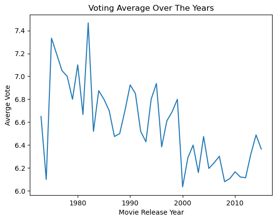

```python
#Let's explore the the movie rating overtime performance with a line plot:

df.groupby(by = "release_year")["vote_average"].mean().plot();
plt.xlabel("Movie Release Year")
plt.ylabel("Averge Vote")
plt.title("Voting Average Over The Years")
plt.show()
```

As we can see from the line chart above, the voting average seems to be going down over the years

## 2 - Is the movie business making more profit over the years or less?

```python
# In order to do this
# we need to create a new column, let's call it profit:

df["profit"] = df.revenue - df.budget
```

```python
# let's also create an adjusted profit column:

df["profit_adj"] = df.revenue_adj - df.budget_adj
```

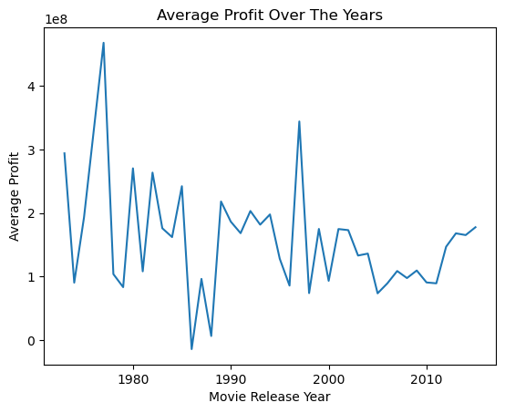

```python
# Now let's see how the profit and the adjusted profit looking over the years:

df.groupby("release_year")["profit"].mean().plot()
plt.xlabel("Movie Release Year")
plt.ylabel("Average Profit")
plt.title("Average Profit Over The Years")
plt.show()
```

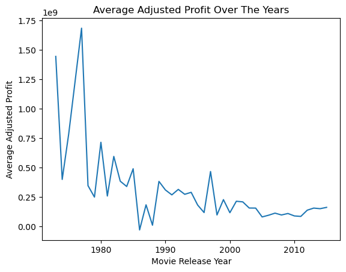

```python
df.groupby("release_year")["profit_adj"].mean().plot()
plt.xlabel("Movie Release Year")
plt.ylabel("Average Adjusted Profit")
plt.title("Average Adjusted Profit Over The Years")
plt.show()
```

In conclusion of the above two chart, it seems like the movie business is making less profit over the years

## 3 - Are the number of movies increasing per year?

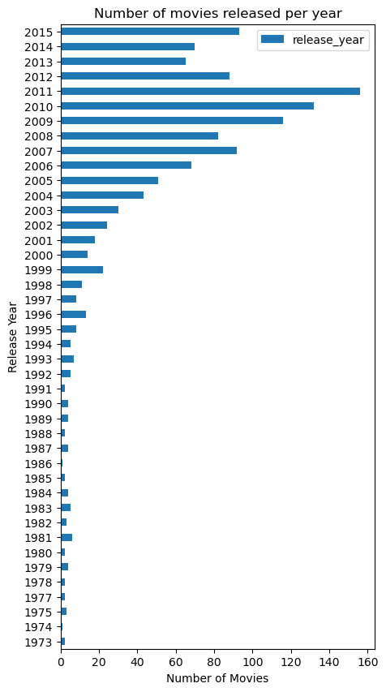

```python
movies_per_year = df["release_year"].value_counts().sort_index()
movies_per_year.plot(kind = "barh", figsize = (5,10), legend = True)
plt.title("Number of movies released per year")
plt.xlabel("Number of Movies")
plt.ylabel("Release Year")
plt.show()
```

## 4 - What's the distribution of the movies runtime values?

```python
df.runtime.describe()
```

```
count    1274.000000
mean      110.199372
std        18.761398
min        63.000000
25%        97.000000
50%       107.000000
75%       121.000000
max       201.000000
Name: runtime, dtype: float64
```

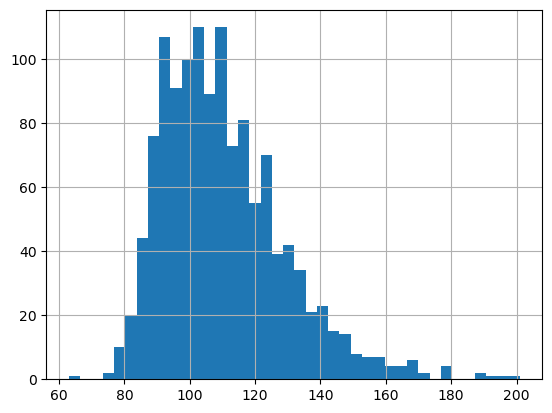

```python
df.runtime.hist(bins = 40);
```

As we can see, most of the movies have duration between 85 and 125 minutes.

- Minimum movie duration is 63 min.
- Maximum movie duration is 201 min.
- Average movie duration is 110 min.
- 25% of the movies have a duration of less than 97 min.
- 50% of the movies have a duration of less than 107 min.
- 75% of the movies have a duration of less than 121 min.

## 5 - What's the relationship between budget spent on a movie and it's popularity?

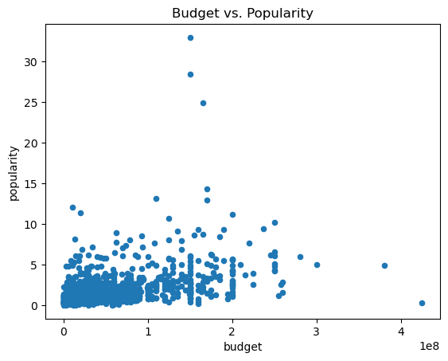

```python
# We can explore the relationship between movies budget and popularity with a scatter plot:

df.plot(kind = "scatter", x = "budget", y = "popularity")
plt.title("Budget vs. Popularity")
plt.show()
```

As we can see, they both seem to have a positive linear relationship, up to a certain point where we can consider the diminishing returns.

## 6 - Finally, what's the relationship between budget spent and profit acquired?

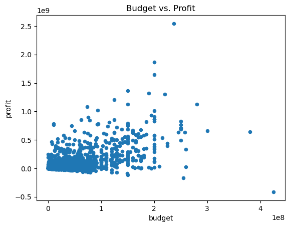

```python
# We can check this by the scatter plot as well:

df.plot(kind = "scatter", x = "budget", y = "profit")
plt.title("Budget vs. Profit")
plt.show()
```

Their Relationship seems to positive linear as well, until a certain point